# Week 8 Homework

Author

Andrew Joyce

Published

March 3, 2024

## Setup and Data Management

```r
library(tidyverse)
library(WeightIt)
library(cobalt)
library(broom)

dict_url <- "https://raw.githubusercontent.com/avehtari/ROS-Examples/master/Childcare/data/datadict.txt"

read_file(dict_url) |>
  writeLines()
```

```
Data Dictionary for Child Care example

The IHDP intervention was implemented in the 1980’s and targeted low
birth weight (less than 2500 grams), pre-term children.  They were
recruited at the time of birth.  It provided high quality child care
and other services in their first 3 years of life.  The comparison
group was pulled from a survey conducted during the same time period
called the National Survey of Longitudinal Youth.  At the time of the
intervention many of the original survey participants (first recruited
in 1979) had children. We have data from those children and their
mothers for an overlapping set of variables (below) as the IHDP
children.

The intervention for low-birth-weight children is described by
- Brooks-Gunn, J., Liaw, F. R., and Klebanov, P. K. (1992). Effects of
  early intervention on cognitive function of low birth weight preterm
  infants. Journal of Pediatrics 120, 350–359.
- Hill, J. L., Brooks-Gunn, J., and Waldfogel, J. (2003). Sustained
  effects of high participation in an early intervention for
  low-birth-weight premature infants. Developmental Psychology 39,
  730–744.

Data columns

"momage"
mom age at time of birth

"b.marr"
indicator for whether mom was married at birth

"momed"
mother’s education level at the time she gave birth

"work.dur"
indicator for whether mom worked in the year before she gave birth

"prenatal"
indicator for whether mom received prenatal care

"cig"
```

[output cut: 28 more lines]

```

"st5", "st9", "st12", "st25", "st36", "st42", "st48", "st53"
indicator for state where household resides

"st99"
indicator for whether family  was living in state served by the ihdp

"income"
family income one year after the child was born

"treat"
indicator for whether family was allowed to receive IHDP services (1 = yes)

"ppvtr.36"
IQ measured at age 36 months
```

```r
var_names <- c("momage", "b.marr", "momed", "work.dur", "prenatal", "cig", "booze", "sex", "first", "bw", "bwg", "preterm", "black", "hispanic", "white", "lths", "hs", "ltcoll", "college", "dayskidh", "st5", "st9", "st12", "st25", "st36", "st42", "st48", "st53", "st99", "income", "treat", "ppvtr.36")

url <- "https://raw.githubusercontent.com/avehtari/ROS-Examples/master/Childcare/data/cc2.csv"

d <- read_csv(url) |>
  select(all_of(var_names)) |>
  mutate(across(matches("st\\d{2}"), as.integer))
glimpse(d)
```

```
Rows: 4,381
Columns: 32
$ momage   <dbl> 33, 22, 13, 25, 19, 19, 26, 20, 23, 28, 32, 23, 29, 18, 25, 1…
$ b.marr   <dbl> 1, 0, 0, 1, 0, 0, 0, 1, 1, 1, 0, 0, 1, 0, 1, 0, 0, 1, 1, 0, 1…
$ momed    <dbl> 4, 1, 1, 4, 1, 2, 1, 1, 2, 2, 1, 2, 1, 1, 4, 1, 1, 1, 2, 1, 3…
$ work.dur <dbl> 1, 0, 0, 1, 0, 1, 1, 0, 1, 1, 1, 1, 0, 0, 1, 0, 1, 1, 1, 1, 1…
$ prenatal <dbl> 1, 1, 1, 1, 1, 1, 1, 1, 1, 1, 1, 1, 1, 1, 1, 1, 1, 1, 1, 1, 1…
$ cig      <dbl> 0, 0, 0, 0, 1, 1, 1, 1, 0, 1, 1, 0, 0, 0, 0, 1, 1, 0, 0, 0, 1…
$ booze    <dbl> 0, 1, 0, 0, 0, 1, 0, 1, 0, 0, 0, 0, 0, 0, 0, 0, 0, 0, 0, 0, 0…
$ sex      <dbl> 1, 1, 1, 1, 1, 0, 1, 0, 0, 1, 0, 0, 1, 1, 0, 1, 0, 1, 0, 1, 1…
$ first    <dbl> 0, 0, 1, 1, 0, 1, 0, 0, 0, 0, 0, 0, 1, 1, 0, 1, 0, 0, 0, 0, 1…
$ bw       <dbl> 1559, 2240, 1900, 1550, 2270, 1550, 2330, 2410, 1776, 2140, 2…
$ bwg      <dbl> 0, 1, 0, 0, 1, 0, 1, 1, 0, 1, 1, 0, 1, 1, 0, 1, 1, 1, 1, 1, 0…
$ preterm  <dbl> 10, 3, 6, 8, 5, 4, 9, 3, 6, 5, 5, 7, 6, 10, 8, 6, 7, 6, 6, 6,…
$ black    <dbl> 0, 1, 1, 1, 1, 1, 0, 0, 0, 1, 0, 1, 0, 1, 0, 0, 0, 0, 1, 1, 0…
```

[output cut: 19 more lines]

```r
## custom love plot
love_plot <- function(x) {
  love.plot(x,
            binary = "std",
            stats = c("m", "ks"),
            thresholds = c(.1, .05)) ## will draw a line at .1 for std dev eventually
}
```

## 8.1.1 Exercise

Gelman & colleagues decided to omit babies with the lowest birth weights (≤ 1500 g) because they were too different from the comparison group. I suppose these extreme low birth weight babies (who hopefully received treatment) did not have matches in the control (untreated) group. Thus, these extremely low birth weights are *outside the region of common support.* The main problem is that dropping these cases could bias our estimates- likely by underestimating the true treatment effect.

While it would be tempting to exclude them, especially if I wanted to calculate an ATE, It would be best to include them. I want to maintain as much information possible about these extreme cases, *especially* if they did receive treatment. Otherwise, our estimates might be smaller than the true effect.

We can see below that the distribution of birth weights are very different for treatment/control groups. Since birthweight affects selection into treatment, I’d want to account for that in estimating a treatment effect.

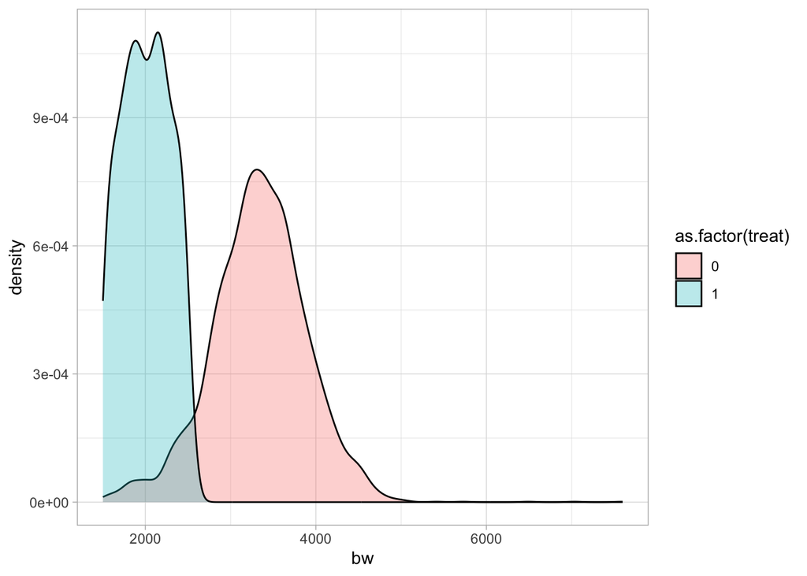

```r
ggplot(data = d,
       aes(x = bw, fill = as.factor(treat)) ) +
  geom_density(alpha = 0.3) +
  theme_light()
```

Our naive estimate is:

```r
mean(d$ppvtr.36[d$treat==1]) - mean(d$ppvtr.36[d$treat==0])
```

```
[1] 6.08574
```

Receiving the treatment increases test score by 6.09 points. But this assumes there is no difference between treatment and control groups (other than treatment), and we know that’s not the case.

## 8.1.2 Exercise

Explicit targets of treatment (low birth weight, living in state where treatment occurs):

- Low birth weight vars (`bw`, `bwg`) and premature var (`preterm`)
- variables related to location: `st5`, `st9`, `st12`, `st25`, `st36`, `st42`, `st48`, `st53`, `st99`

Maternal & environmental characteristics that could affect both birthweight (which in turn affects selection into treatment) & our outcome IQ variable:

- `momage`, `b.marr`, `momed` (and/or series of indicators for mom’s education: `lths`, `hs`, `ltcoll`, `college`), `work.dur`, `prenatal`, `cig`, `booze`, `income`

Other child characteristics that could affect selection into treatment & outcome variable:

- `sex`, `first`, `black`, `hispanic`, `white`, `dayskidh`

You can see my different attempts at formulas that “work.”

Interestingly, entropy balancing does not work until version #5.

Here’s the logic of what I ended up including:

```r
trt_form_1 <- "treat ~ bw + bwg + preterm +
                     st5 + st9 + st12 + st25 + st36 + st42 + st48 + st53 + st99 +
                     momage + I(momage^2) + b.marr + lths + hs + ltcoll + college +
                     work.dur + prenatal + cig + booze + income +
                     sex + first + black + hispanic + white + dayskidh"

trt_form_2 <- "treat ~ bw + bwg + preterm + st99 +
                     momage + I(momage^2) + b.marr + lths + hs + ltcoll + college +
                     work.dur + prenatal + cig + booze + income +
                     sex + first + black + hispanic + white + dayskidh"

trt_form_3 <- "treat ~ bw + preterm + st99 +
                     momage + I(momage^2) + b.marr + momed +
                     work.dur + prenatal + cig + booze + income +
                     sex + first + black + hispanic + white"

trt_form_4 <- "treat ~ bw + bwg + preterm + st99 +
                     momage + I(momage^2) + b.marr + momed +
                     work.dur + prenatal + income +
                     sex + first + black + hispanic + white"

trt_form_5 <- "treat ~ bw + bwg + st99 +
                     momage + I(momage^2) + b.marr + momed +
                     work.dur + prenatal  +
                     sex + first + black + hispanic + white" ## FIRST TIME EBAL WORKS

trt_form_6 <- "treat ~ bwg + st99 +
                     momage + I(momage^2) + b.marr + lths + hs + ltcoll + college +
                     work.dur + prenatal  + income +
                     sex + first + black + hispanic + white"
```

## 8.1.3 Exercise

### Using PSM

```r
## first attempt
W1 <- weightit(as.formula(trt_form_1),
               method = "ps",
               estimand = "ATT",
               data = d)
summary(W1)
```

```
                 Summary of weights

- Weight ranges:

        Min                                   Max
treated   1  ||                            1.0000
control   0 |---------------------------| 43.8502

- Units with the 5 most extreme weights by group:

              8       5       3       2       1
 treated      1       1       1       1       1
           3679    2801    2577    1430    2802
 control 8.8053 10.1796 27.9729 43.0751 43.8502

- Weight statistics:

        Coef of Var   MAD Entropy # Zeros
treated       0.000 0.000  -0.000       0
control      24.301 1.957   5.798    3102

- Effective Sample Sizes:

           Control Treated
Unweighted 4091.       290
Weighted      6.92     290
```

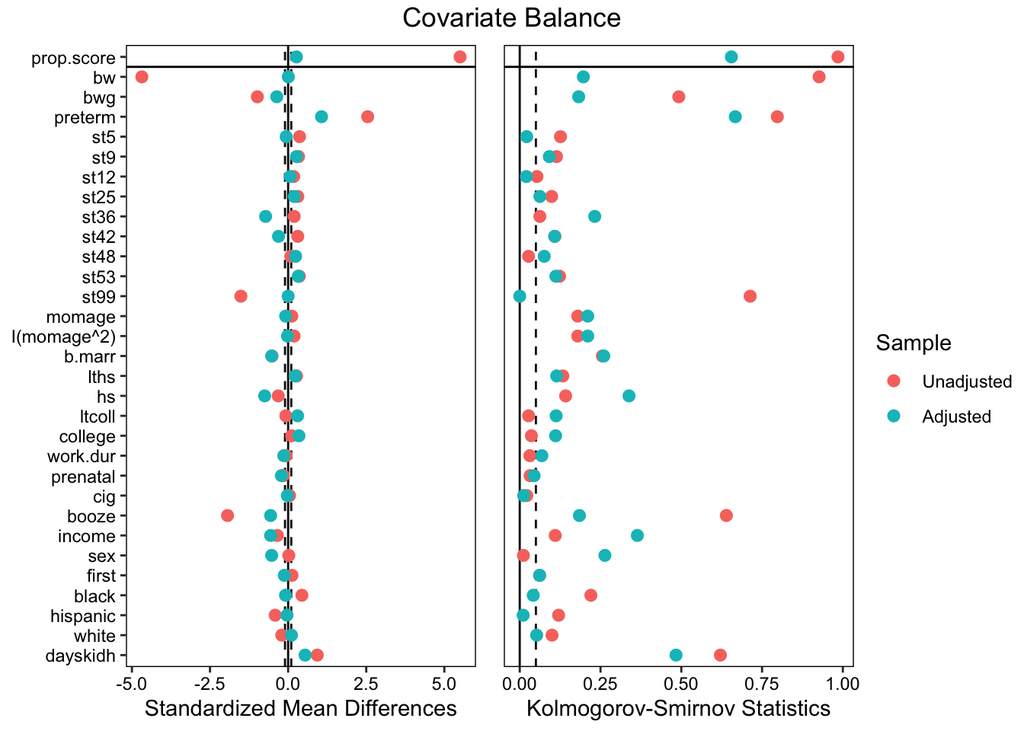

```r
love_plot(W1)
```

```r
## final attempt
W2 <- weightit(as.formula(trt_form_6),
               method = "ps",
               estimand = "ATT",
               data = d)
summary(W2)
```

```
                 Summary of weights

- Weight ranges:

        Min                                   Max
treated   1  ||                            1.0000
control   0 |---------------------------| 20.6244

- Units with the 5 most extreme weights by group:

              7       6       4       2       1
 treated      1       1       1       1       1
           2831    1129    1133    2577     811
 control 9.6565 10.6284 11.7546 13.2091 20.6244

- Weight statistics:

        Coef of Var   MAD Entropy # Zeros
treated       0.000 0.000  -0.000       0
control       8.909 1.576   3.029    2902

- Effective Sample Sizes:

           Control Treated
Unweighted 4091.       290
Weighted     50.92     290
```

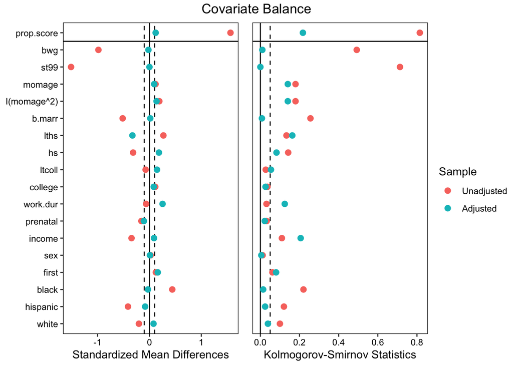

```r
love_plot(W2)
```

The variables are not well-balanced after adjustment (especially their KSDs). Let’s try different methods.

### Using CBPS

```r
CBPS1 <- weightit(as.formula(trt_form_1),
               method = "CBPS",
               estimand = "ATT",
               data = d)
summary(CBPS1)
```

```
                 Summary of weights

- Weight ranges:

        Min                                   Max
treated   1   ||                           1.0000
control   0 |---------------------------| 17.4203

- Units with the 5 most extreme weights by group:

              5      4      3       2       1
 treated      1      1      1       1       1
            339   1732   1915    2802    3007
 control 8.6351 8.9282 9.2485 13.6543 17.4203

- Weight statistics:

        Coef of Var   MAD Entropy # Zeros
treated       0.000 0.000  -0.000       0
control      14.236 1.952   5.004       0

- Effective Sample Sizes:

           Control Treated
Unweighted 4091.       290
Weighted     20.09     290
```

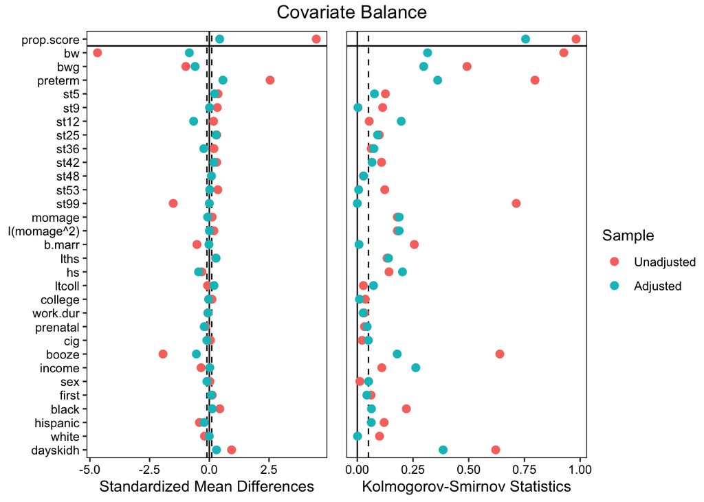

```r
love_plot(CBPS1)
```

```r
## final attempt
CBPS2 <- weightit(as.formula(trt_form_6),
               method = "CBPS",
               estimand = "ATT",
               data = d)
summary(CBPS2)
```

```
                 Summary of weights

- Weight ranges:

        Min                                   Max
treated   1   ||                           1.0000
control   0 |---------------------------| 16.7639

- Units with the 5 most extreme weights by group:

              6      4      3      2       1
 treated      1      1      1      1       1
           2831   2577   1133   1129     811
 control 6.4227 8.7031 8.7765 8.8507 16.7639

- Weight statistics:

        Coef of Var   MAD Entropy # Zeros
treated        0.00 0.000  -0.000       0
control        7.11 1.544   2.652       0

- Effective Sample Sizes:

           Control Treated
Unweighted 4091.       290
Weighted     79.37     290
```

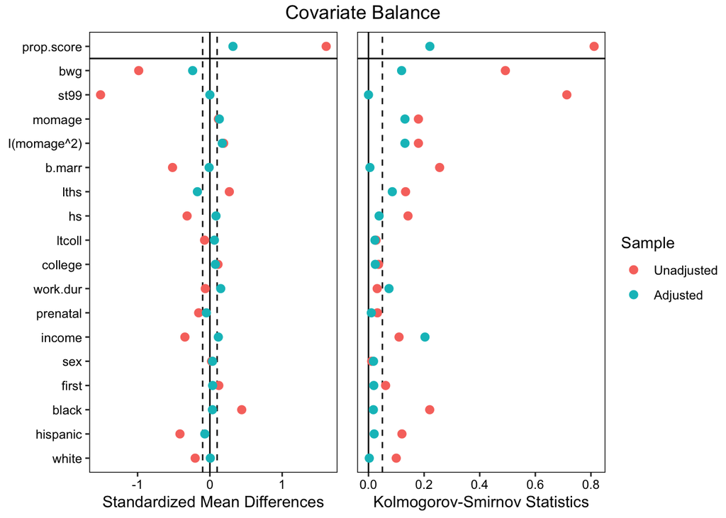

```r
love_plot(CBPS2)
```

### Using Entropy Balancing

```r
EBAL1 <- weightit(as.formula(trt_form_1),
               method = "ebal",
               estimand = "ATT",
               data = d)
summary(EBAL1)
```

```
                 Summary of weights

- Weight ranges:

        Min                                 Max
treated   1                              ||   1
control   0   ||                              0

- Units with the 5 most extreme weights by group:

           5   4   3   2    1
 treated   1   1   1   1    1
         294 293 292 291 4206
 control   0   0   0   0    0

- Weight statistics:

        Coef of Var MAD Entropy # Zeros
treated           0   0       0       0
control                       0    4091

- Effective Sample Sizes:

           Control Treated
Unweighted    4091     290
Weighted               290
```

```r
# love_plot(EBAL1) impossible to render, all weights are zero

## final attempt
EBAL2 <- weightit(as.formula(trt_form_6),
               method = "ebal",
               estimand = "ATT",
               data = d)
summary(EBAL2)
```

```
                 Summary of weights

- Weight ranges:

        Min                                    Max
treated   1 ||                              1.0000
control   0 |---------------------------| 465.6735

- Units with the 5 most extreme weights by group:

                5        4        3        2        1
 treated        1        1        1        1        1
              811     3099     1133     1129      401
 control 238.5608 245.1328 328.4998 444.7832 465.6735

- Weight statistics:

        Coef of Var   MAD Entropy # Zeros
treated       0.000 0.000   0.000       0
control      14.331 1.897   4.682    2833

- Effective Sample Sizes:

           Control Treated
Unweighted 4091.       290
Weighted     19.83     290
```

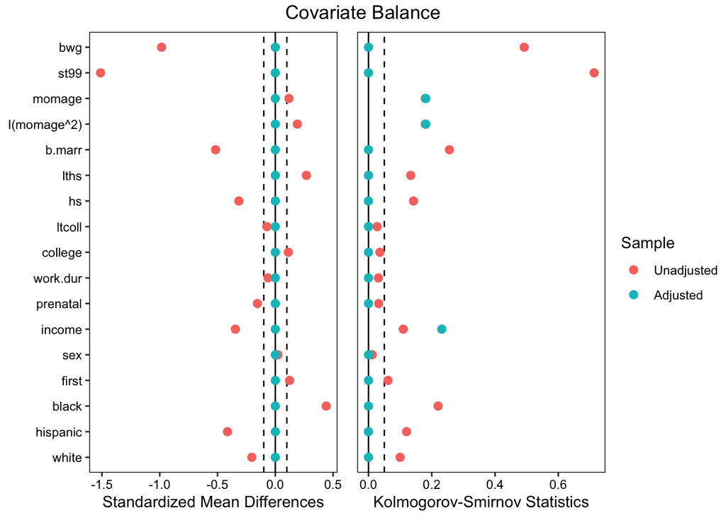

```r
love_plot(EBAL2)
```

### ATT Estimate using EB

```r
ebal_att <- lm(ppvtr.36 ~ treat,
               data = d,
               weights = EBAL2$weights)
tidy(ebal_att, conf.int = TRUE)
```

```
# A tibble: 2 × 7
  term        estimate std.error statistic      p.value conf.low conf.high
  <chr>          <dbl>     <dbl>     <dbl>        <dbl>    <dbl>     <dbl>
1 (Intercept)    84.9      0.338    252.   0               84.2      85.6
2 treat           7.21     1.31       5.50 0.0000000406     4.64      9.79
```

Using entropy balancing, our estimated effect of receiving treatment is an increase in IQ by 7.21 points.